# MTH6139 Time Series

Coursework 1 - Forecasting the GBP/USD Exchange Rate with Prophet

Mohammad Ruhan-Ur Rahman

Spring Term 2025

# Introduction

This project analyses the GBP/USD exchange rate using Meta’s Prophet model. The goal is to explore how the exchange rate behaves over time, identify patterns such as trends or seasonality, and produce a short-term forecast.

The GBP/USD exchange rate measures how many US dollars one British pound can buy. It is one of the most traded currency pairs in the world and is influenced by economic conditions, interest rates, and global events. This makes it a realistic and interesting dataset compared to standard classroom examples.

# Data and setup

The data consists of daily GBP/USD exchange rates downloaded from Yahoo Finance starting from 2020. Using daily data allows us to capture short-term fluctuations and better understand the volatility of the market.

```r
library(quantmod)
library(prophet)
library(ggplot2)

getSymbols("GBPUSD=X", src = "yahoo", from = "2020-01-01")
```

```
## [1] "GBPUSD=X"
```

```r
gbp_usd_data <- data.frame(
  ds = as.Date(index(`GBPUSD=X`)),
  y = as.numeric(Cl(`GBPUSD=X`))
)
```

# Exploratory analysis

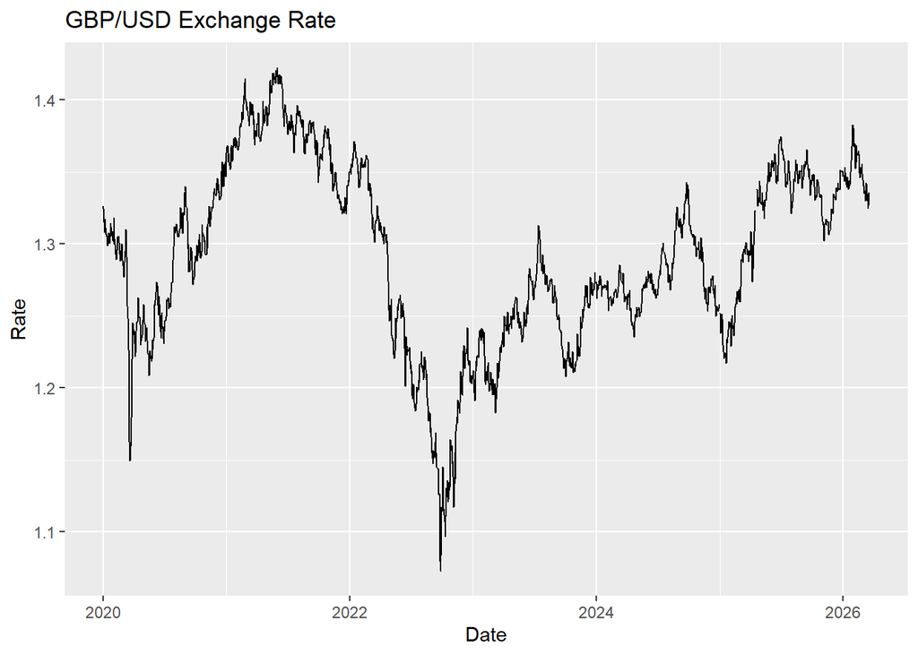

```r
ggplot(gbp_usd_data, aes(x = ds, y = y)) +
  geom_line() +
  labs(title = "GBP/USD Exchange Rate", x = "Date", y = "Rate")
```

The plot shows that the exchange rate moves up and down frequently, with no obvious repeating pattern. There are periods of sharp increases and decreases, reflecting the impact of economic and political events on currency markets.

```r
summary(lm(y ~ ds, data = gbp_usd_data))
```

```
##
## Call:
## lm(formula = y ~ ds, data = gbp_usd_data)
##
## Residuals:
##       Min        1Q    Median        3Q       Max
## -0.219377 -0.043111 -0.000975  0.052710  0.129087
##
## Coefficients:
##               Estimate Std. Error t value Pr(>|t|)
## (Intercept)  1.350e+00  4.649e-02  29.045   <2e-16 ***
## ds          -3.016e-06  2.396e-06  -1.259    0.208
## ---
## Signif. codes:  0 '***' 0.001 '**' 0.01 '*' 0.05 '.' 0.1 ' ' 1
##
## Residual standard error: 0.06313 on 1616 degrees of freedom
##   (6 observations deleted due to missingness)
## Multiple R-squared:  0.00098,    Adjusted R-squared:  0.0003618
## F-statistic: 1.585 on 1 and 1616 DF,  p-value: 0.2082
```

A simple linear trend model suggests that although the exchange rate changes over time, it does not follow a stable upward or downward path. This highlights the difficulty of modelling financial time series using simple methods.

# Prophet model

```r
model <- prophet(gbp_usd_data)

future <- make_future_dataframe(model, periods = 30)

forecast <- predict(model, future)
```

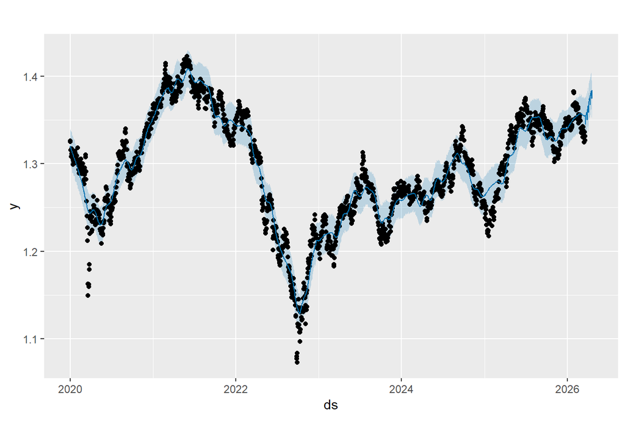

```r
plot(model, forecast)
```

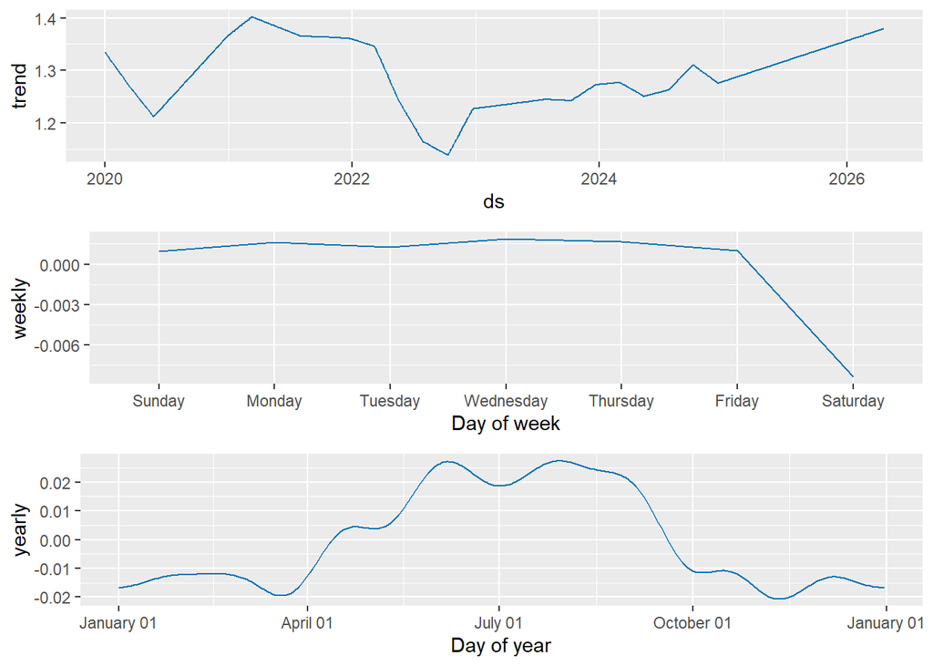

```r
prophet_plot_components(model, forecast)
```

The component plots separate the data into trend and seasonal effects. In this case, the trend is the dominant feature, while seasonal components are relatively weak.

# Alternative model

```r
model2 <- prophet(gbp_usd_data,
                  weekly.seasonality = FALSE,
                  yearly.seasonality = FALSE)

forecast2 <- predict(model2, make_future_dataframe(model2, periods = 30))
```

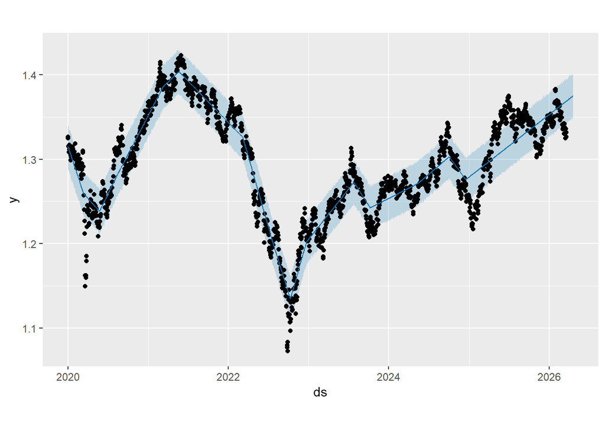

```r
plot(model2, forecast2)
```

Removing seasonality does not significantly change the forecast results. This supports the earlier observation that the GBP/USD series does not exhibit strong seasonal behaviour.

# Discussion

Compared to smoother datasets such as CO2 concentrations, exchange rate data is highly volatile and affected by unpredictable external factors. This makes forecasting more challenging and means that results should be interpreted with caution.

# Conclusion

The GBP/USD exchange rate shows significant volatility and weak seasonal patterns. Prophet provides a flexible and easy-to-use framework for analysing and forecasting such data, although the uncertainty in predictions remains high due to the nature of financial markets.

# References

- Prophet documentation: https://facebook.github.io/prophet/docs/quick_start.html#r-api
- Yahoo Finance: https://finance.yahoo.com